# Nitrogen cycle associated bacteria

Jared

9/6/2019

## The Nitrogen Cycle

The Nitrogen cycle is important in many ecological systems including agriculture and particullarly for organic agriculture. Organic crop production is dependent on soil microbes to generate plant available nitrogen from decomposition of manures, composts or green-manures.

[figure not shown]

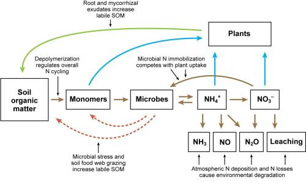

### Step 1: decomposition and ammonium production

Most nitrogen entering organic agroecosystems is in the form of proteins released from decomposing animal and plant tissues or wastes. Proteases in soil bacteria convert the proteins to polypeptides and amino acids. Deamination of these amino acids produces ammonia (NH<sub>3</sub>) that generally disolves in soil water to generate ammonium ions (NH<sub>4</sub><sup>+</sup>), one form of inorganic N that plants can utilize for growth. In addition to amino acids, there are other compounds in the soil that go through the ammonification process like nucleic acids, urea, and uric acid. The soil bacteria reponsible for this are called ammonifying bacteria. These include members of the following genra:  
*Bacillus*  
*Clostridium*  
*Proteus*  
*Pseudomonas*  
*Streptomyces*

#### Abundance of ammonifying genera in incubated microcosms

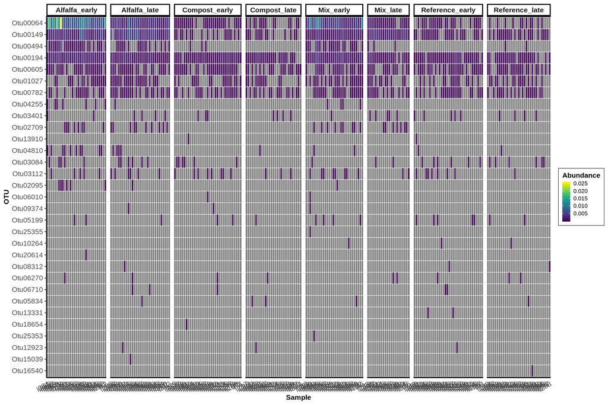

```r
# Subset to desired samples and genera, remove low count taxa. Then rarefy.
Ammonifying.phy <- subset_samples(inc.physeq, day %in% c("7","14","21","35","49","97")) %>%
  rarefy_even_depth(sample.size = 6000, rngseed = 909090) %>%
  filter_taxa(function(x) sum(x) >= 1, T) %>%
  transform_sample_counts(function(x) {x/sum(x)}) %>%
  subset_taxa(Genus %in% c("Bacillus", "Clostridium", "Proteus", "Pseudomonas", "Streptomyces"))

abundance_heatmap(Ammonifying.phy, classification = NULL, treatment = "Treatment_Response", subset = NULL, transformation = 'none', colors = 'default')
```

##### What is Otu00064?

```r
as.data.frame(Ammonifying.phy@tax_table) %>%
  filter(row.names(.) %in% c("Otu00064"))
```

```
##    Kingdom         Phylum               Class           Order
## 1 Bacteria Proteobacteria Gammaproteobacteria Pseudomonadales
##             Family       Genus
## 1 Pseudomonadaceae Pseudomonas
```

### Step 2: oxidation of ammonium to nitrate

While ammonium may be taken up by plants, the other form of inorganic nitrogen utilized is nitrate NO<sub>3</sub>. The production of nitrate is two step, first oxidation of ammonium to nitrite and then oxidation of nitrite to nitrate. These two steps are carried out by two groups of bacteria, ammonia oxidizing bacteria (AOB) and nitrite oxidizing bacteria (NOB).

#### AOB associated genera

*Nitrosomonas*  
*Nitrosospira*  
*Nitrosovibrio*  
*Nitrosolobus*  
*Nitrosococcus*

#### Abundance of AOB genera in incubated microcosms

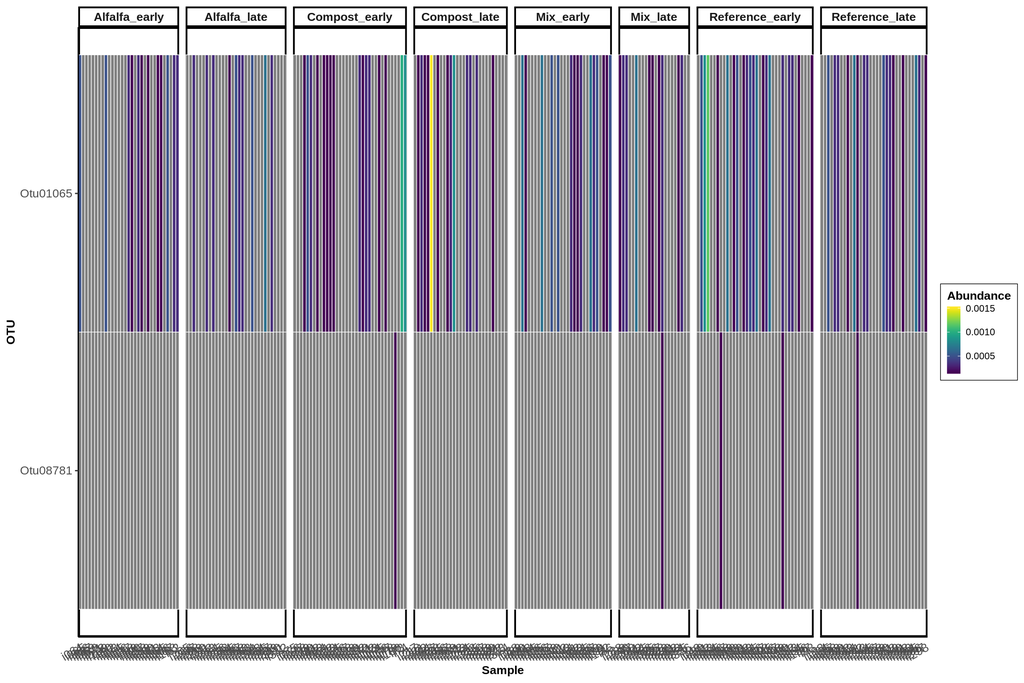

```r
# Subset to desired samples and genera, remove low count taxa. Then rarefy.
AOB.phy <- subset_samples(inc.physeq, day %in% c("7","14","21","35","49","97")) %>%
  rarefy_even_depth(sample.size = 6000, rngseed = 909090) %>%
  filter_taxa(function(x) sum(x) >= 1, T) %>%
  transform_sample_counts(function(x) {x/sum(x)}) %>%
  subset_taxa(Genus %in% c("Nitrosomonas", "Nitrosospira", "Nitrosovibrio", "Nitrosolobus", "Nitrosococcus"))

abundance_heatmap(AOB.phy, classification = NULL, treatment = "Treatment_Response", subset = NULL, transformation = 'none', colors = 'default')
```

##### What is Otu01065?

```r
as.data.frame(AOB.phy@tax_table) %>%
  filter(row.names(.) %in% c("Otu01065"))
```

```
##    Kingdom         Phylum              Class            Order
## 1 Bacteria Proteobacteria Betaproteobacteria Nitrosomonadales
##              Family        Genus
## 1 Nitrosomonadaceae Nitrosospira
```

#### NOB associated genera

*Nitrobacter*  
*Nitrospina*  
*Nitrococcus*  
*Nitrospira*

#### Abundance of NOB genera in incubated microcosms

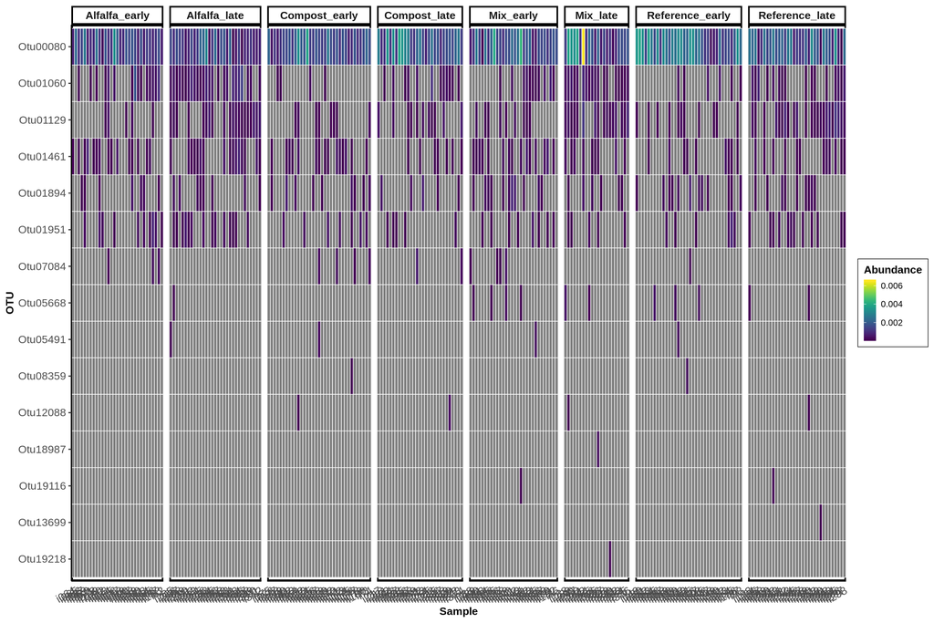

```r
# Subset to desired samples and genera, remove low count taxa. Then rarefy.
NOB.phy <- subset_samples(inc.physeq, day %in% c("7","14","21","35","49","97")) %>%
  rarefy_even_depth(sample.size = 6000, rngseed = 909090) %>%
  filter_taxa(function(x) sum(x) >= 1, T) %>%
  transform_sample_counts(function(x) {x/sum(x)}) %>%
  subset_taxa(Genus %in% c("Nitrobacter", "Nitrospina", "Nitrococcus", "Nitrospira"))

abundance_heatmap(NOB.phy, classification = NULL, treatment = "Treatment_Response", subset = NULL, transformation = 'none', colors = 'default')
```

##### What is Otu00080?

```r
as.data.frame(NOB.phy@tax_table) %>%
  filter(row.names(.) %in% c("Otu00080"))
```

```
##    Kingdom      Phylum      Class         Order         Family      Genus
## 1 Bacteria Nitrospirae Nitrospira Nitrospirales Nitrospiraceae Nitrospira
```